# Sparse Sim

Test to show our calculations are accurate:

Compare RMSE:

```r
mle=as.matrix(wfull)
beta=as.matrix(c$beta)

mash.nobaselinemeans=as.matrix(read.table("sparseLposterior.means.txt")[,-1])
mash.means=as.matrix(read.table("sparseoldmashposterior.means.txt")[,-1])

standard=sqrt(mean((beta-mle)^2))
sqrt(mean((mash.means-beta)^2))/standard
```

```
## [1] 0.8212081
```

```r
sqrt(mean((mash.nobaselinemeans-beta)^2))/standard
```

```
## [1] 0.8508868
```

Let’s look at a few examples:

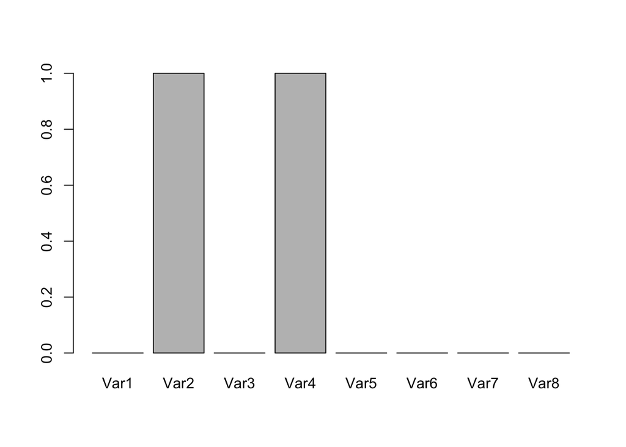

```r
barplot(c$factors[2,])
```

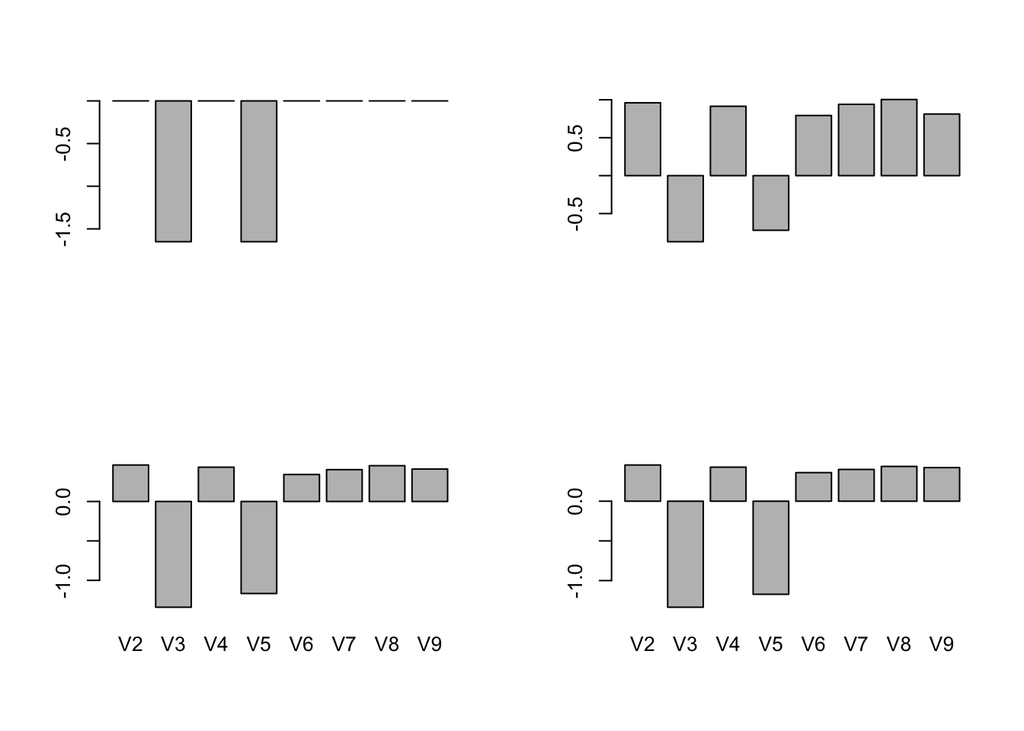

```r
j=which(c$components==2)[2]

par(mfrow=c(2,2))
barplot(c$beta[j,])
barplot(c$chat[j,]-mean(c$chat))
barplot(mash.nobaselinemeans[j,])
barplot(mash.means[j,])
```

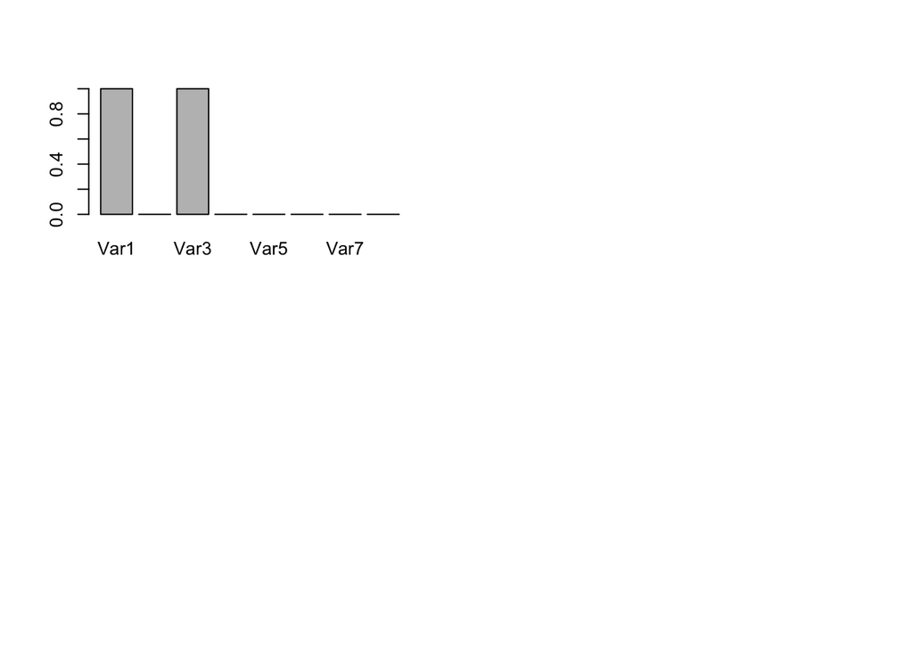

```r
barplot(c$factors[3,])
j=which(c$components==3)[4]


par(mfrow=c(2,2))
```

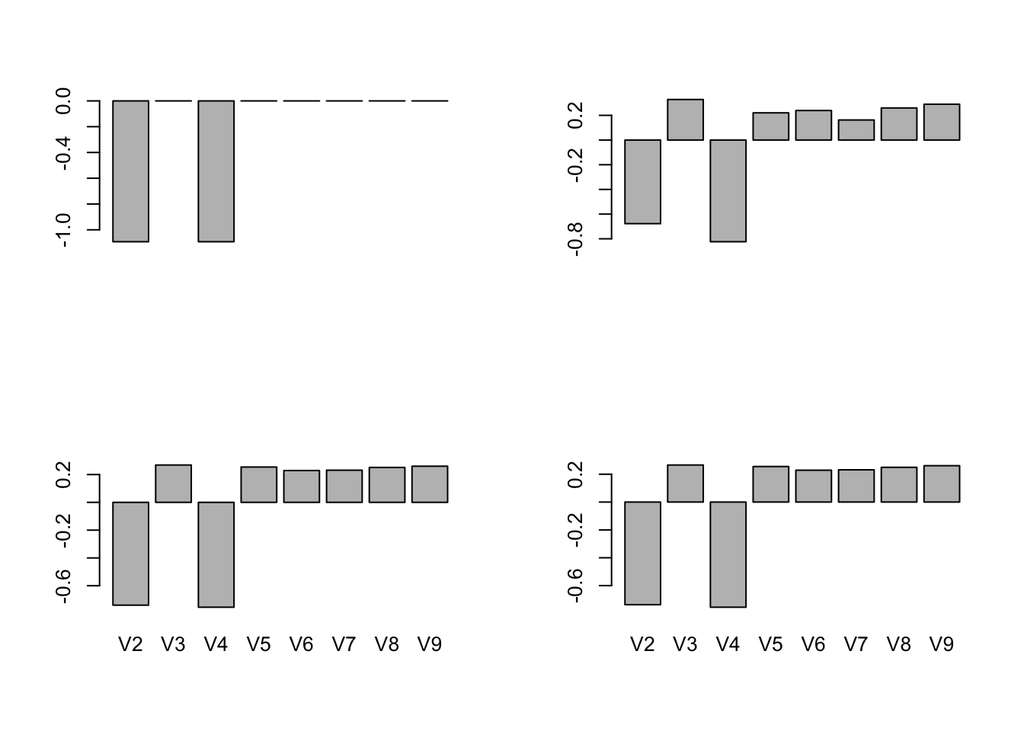

```r
barplot(c$beta[j,])
barplot(c$chat[j,]-mean(c$chat[j,]))
barplot(mash.nobaselinemeans[j,])
barplot(mash.means[j,])
```

Show ROC curves:

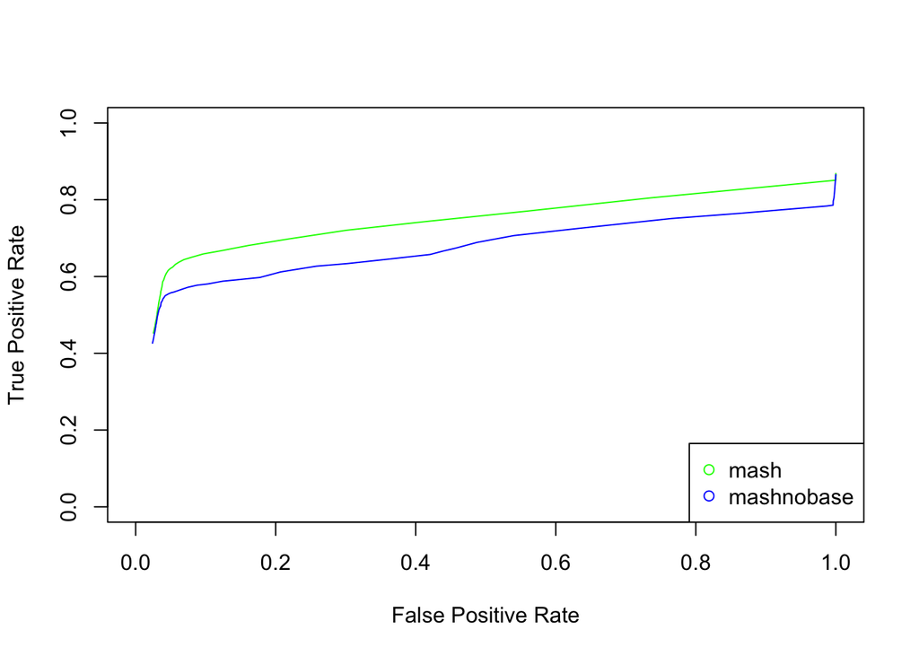

## Comparing with truth.

Now, let’s try this with the true prior. Here, we use the covariance matrices that were used to simulate the data as the output of *c$covmat*

We can have a look at the them first:

```r
rm(list=ls())
c=readRDS("~/mashnobaseline/Simulations/sparsesim/chatsimesparsef.rds")
t(sapply(c$covmat,function(x){diag(x)}))
```

```
##       [,1] [,2] [,3] [,4] [,5] [,6] [,7] [,8]
##  [1,]    1    1    1    0    0    0    1    1
##  [2,]    0    1    0    1    0    0    0    0
##  [3,]    1    0    1    0    0    0    0    0
##  [4,]    1    0    0    0    0    1    0    1
##  [5,]    0    0    1    0    0    0    0    0
##  [6,]    1    0    1    1    1    1    1    1
##  [7,]    0    1    1    0    0    0    0    0
##  [8,]    0    0    0    0    1    1    0    0
##  [9,]    0    1    1    0    1    1    1    0
## [10,]    0    1    0    1    1    0    1    0
```

So we can see that covariance matrix 1 for instance corresponded to have loading on tissues 1,2,3, 7 and 8 while covariance matrix 10 had strong loading on tissues 2,4,5 and 7.

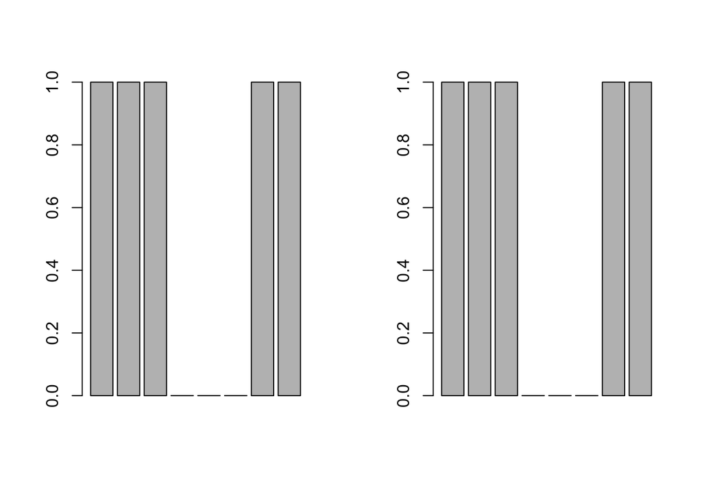

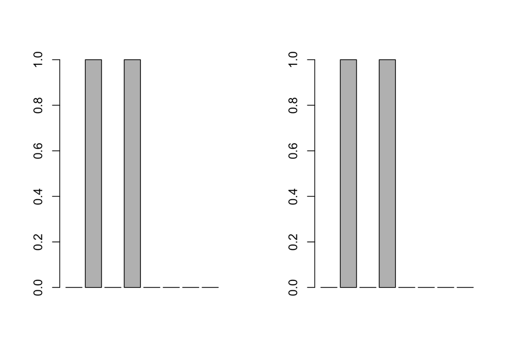

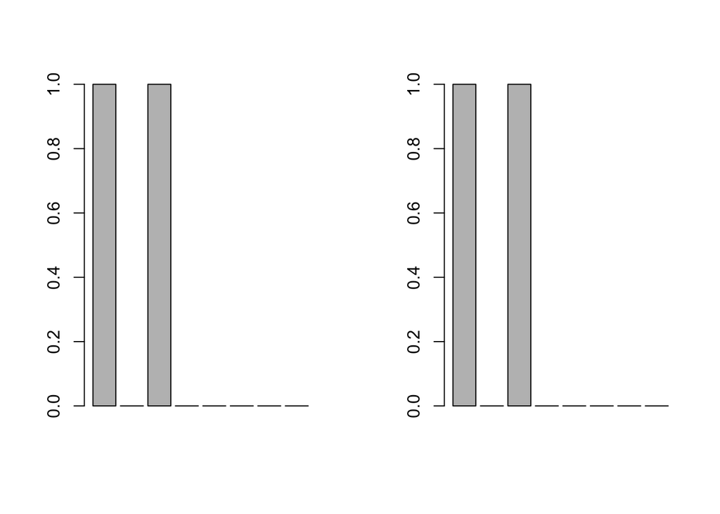

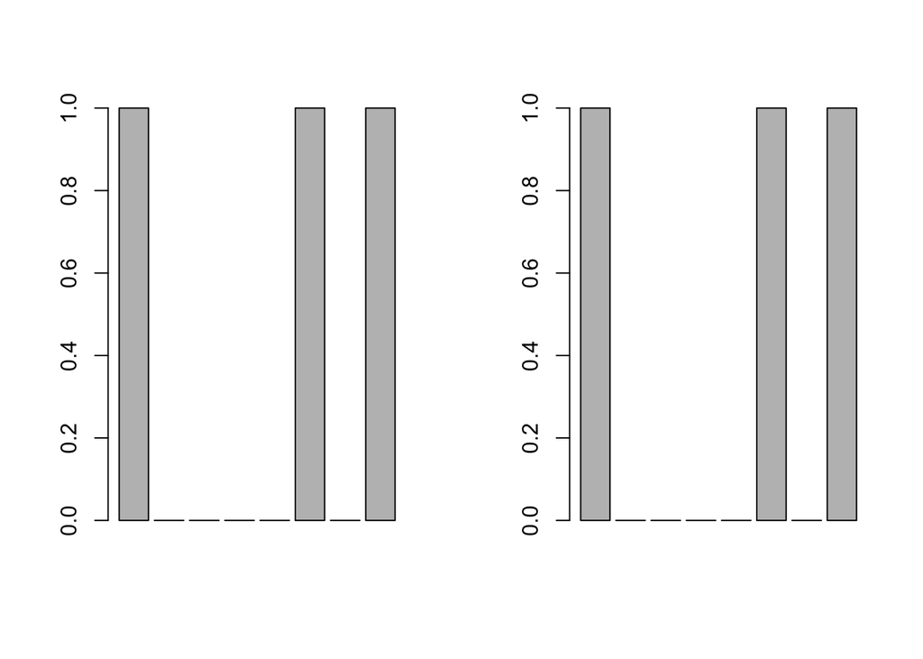

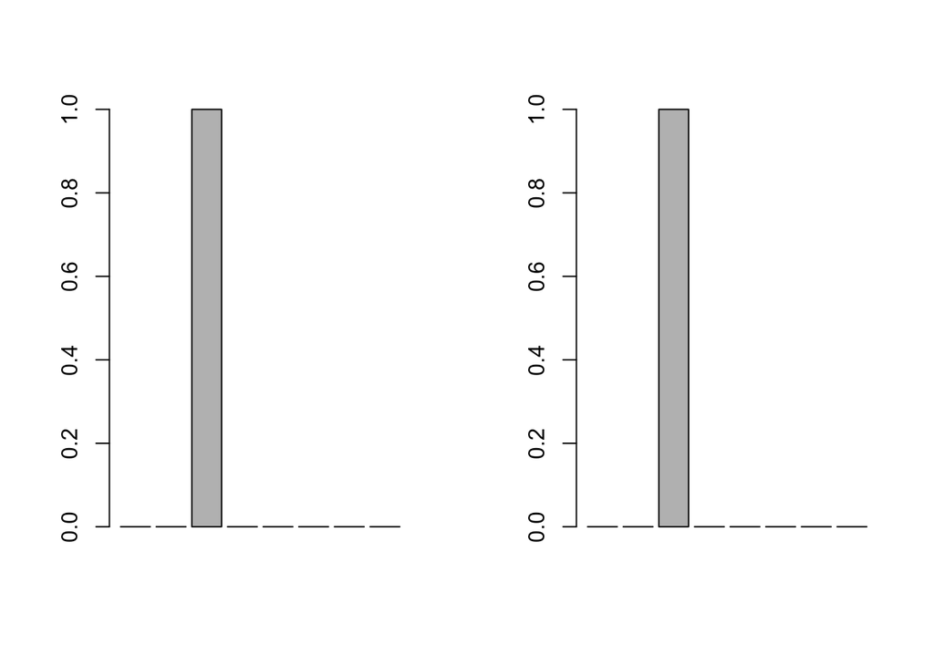

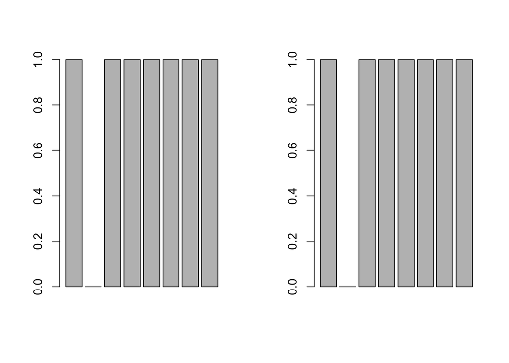

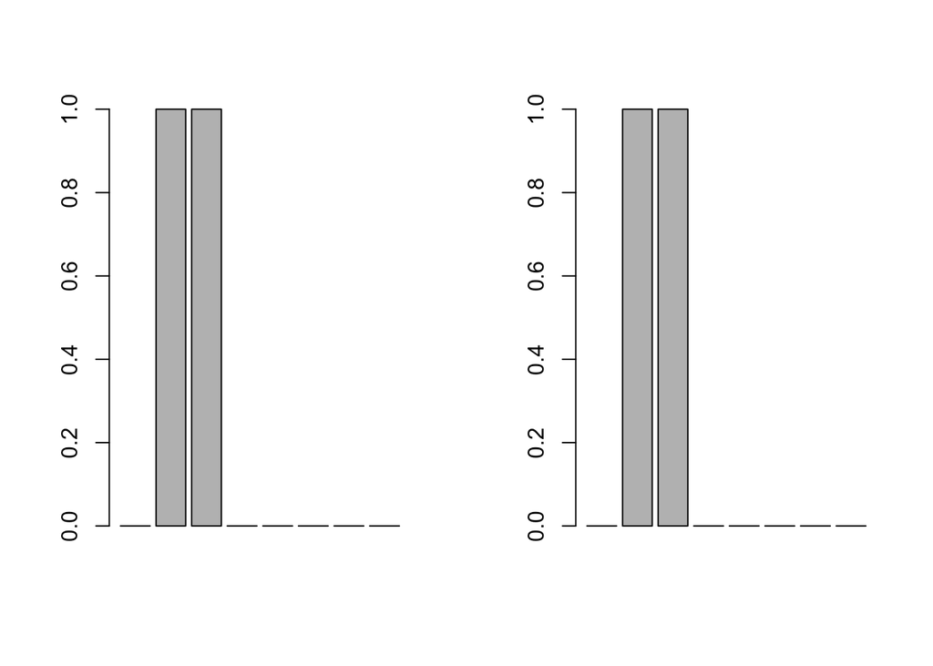

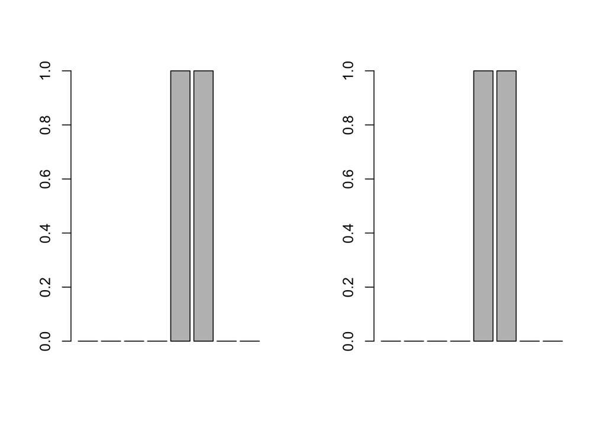

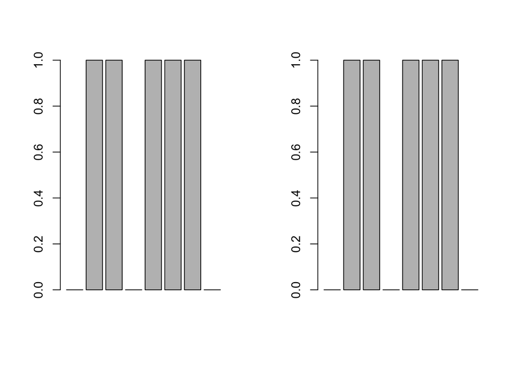

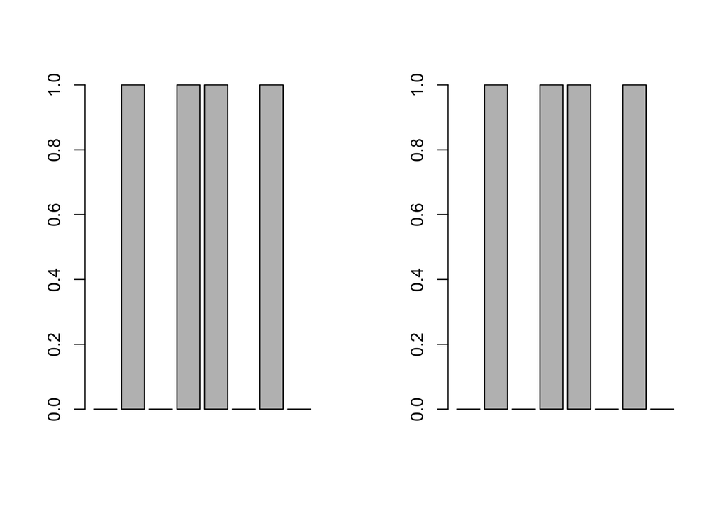

```r
c=readRDS("~/mashnobaseline/Simulations/sparsesim/chatsimesparsef.rds")
source("~/matrix_ash/R/truthscripts.R")
t=c$t;b=c$chat;se=c$shat
#hist(t)
#hist(b)
R=ncol(t)
L=diag(R)-1/R*as.vector(rep(1,R))%*%t(as.vector(rep(1,R)))
wfull=t(L%*%t(b))
sjmat=convertstandarderrors(s.j = se,L=L)##make this be the standard errors of all, it is
covs=compute.covmat.using.truth(b.gp.hat = wfull,sebetahat = sjmat,A="test",zero=TRUE,covlist=c$covmat,power=2)
for(i in 2:11){
  par(mfrow=c(1,2))
  barplot(diag(covs[[i]])/max(diag(covs[[i]])))
  barplot(diag(c$covmat[[i-1]])/max(diag(c$covmat[[i-1]])))
}
```

```r
w=data.frame(wfull)[,-1]
```

```r
A="sparseLwithtruth"


compute.hm.train.log.lik.pen.with.L(w,se.train = se,covmat = covs,A = A,pen = 1,L = L[-1,])
pis=readRDS(paste0("pis",A,".rds"))$pihat

likmat=readRDS(paste0("liketrain",A,".rds"))
test=exp(likmat)
sum(log(test%*%pis))


for(j in 1:nrow(w)){
total.quant.per.snp.no.baseline(j = j,covmat = covs,b.gp.hat = w,se.gp.hat = se,pis = pis,A = A,checkpoint = F,L = L[-1,])}
```

## Test to show our calculations are accurate:

And let’s also do this with the mash framework:

```r
rm(list=ls())
c=readRDS("~/mashnobaseline/Simulations/sparsesim/chatsimesparsef.rds")
source("~/matrix_ash/R/truthscripts.R")
t=c$t;b=c$chat;se=c$shat

R=ncol(t)
L=diag(R)-1/R*as.vector(rep(1,R))%*%t(as.vector(rep(1,R)))
wfull=t(L%*%t(b))
sjmat=convertstandarderrors(s.j = se,L=L)##make this be the standard errors of all, it is
covs=compute.covmat.using.truth(b.gp.hat = wfull,sebetahat = sjmat,A="test",zero=TRUE,covlist=c$covmat,power=2)
```

```r
A="mashtruth"
covs=readRDS("covmattest.rds")
compute.hm.train.log.lik.pen(train.b = wfull,se.train = se,covmat = covs,A=A,pen=1)


pis=readRDS(paste0("pis",A,".rds"))$pihat


weightedquants=lapply(seq(1:nrow(wfull)),function(j){total.quant.per.snp(j,covs,b.gp.hat=wfull,se.gp.hat = se,pis,A=A,checkpoint = FALSE)})
```

Let’s do the same thing comparing the pis using mash from the truth and from mashnobaseline:

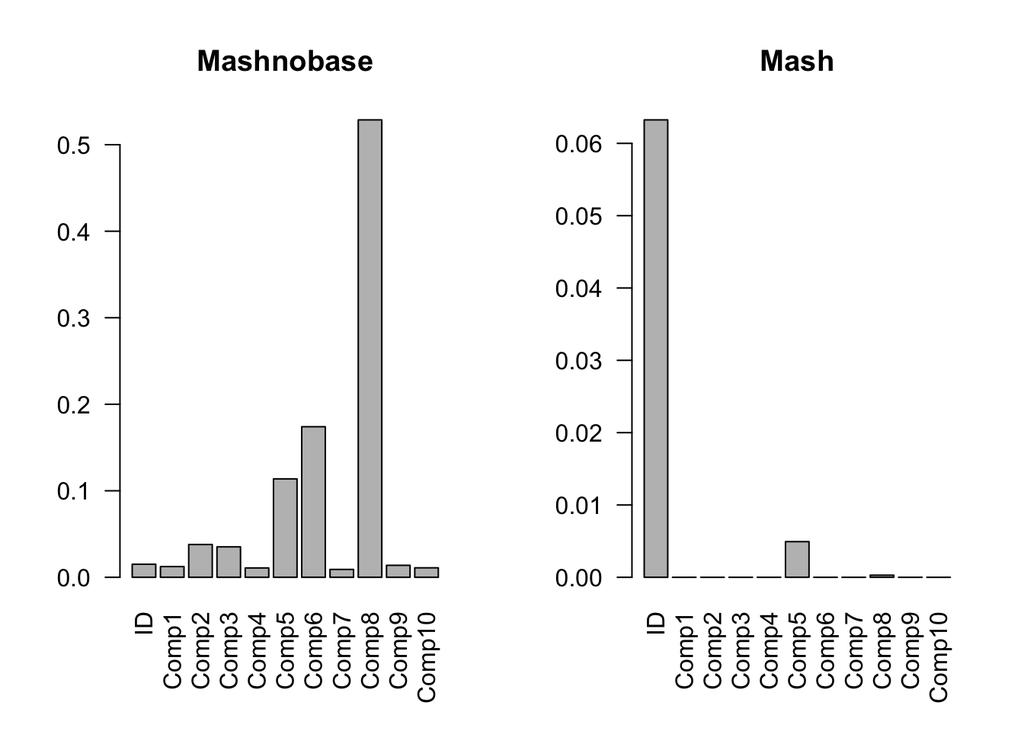

```r
pimash=readRDS("pismashtruth.rds")$pihat
pied=readRDS("pissparseLwithtruth.rds")$pihat
par(mfrow=c(1,2))
barplot(colSums(matrix(pied[-243],ncol=11,byrow=TRUE)),names=c("ID",rep(paste0("Comp",seq(1:10)))),las=2,main="Mashnobase")
barplot(colSums(matrix(pimash[-243],ncol=11,byrow=TRUE)),names=c("ID",rep(paste0("Comp",seq(1:10)))),las=2,main="Mash")
```

We can see that using the same set of covariance matrices, *mashnobaseline* is better able to emphasize the true configurations because the likelihood and posterior computations incorporate L. Recall, for mash:

$w_{j,R} ~ N(0,V+U)$ $w_{j,R-1} ~ N(0,LVL' + LUL')$ where L is the R-1 x R centering matrix.

In both:

$c = \mu + \beta$ $chat = c + E$ $v \sim \sum_p N(0,Uk)$ $E \sim N(0,V)$